# FigureYa319ContribScore

**Author(s)**: Xiaofan Lu; Yasi Zhang  
**Reviewer(s)**: Ying Ge  
**Date**: 2025-05-20

# 需求描述

# Requirements Description

想众筹这个a图，怎么去算单细胞某个细胞亚群对疾病贡献度，知道哪些细胞亚群最重要。

We want to crowdfund this panel A figure, how to calculate the disease contribution score of single cell subsets and identify the most important ones.

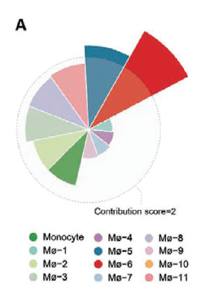

出自：https://onlinelibrary.wiley.com/doi/10.1002/smtd.202100752

图6. 丹参酮IIA治疗通过抑制早期浸润的巨噬细胞亚群减轻病理性心肌梗死进展的效果验证 A) 不同巨噬细胞亚群对疾病的贡献度。半径大小与贡献分数成正比。具体方法详见实验方法部分。

Source: https://onlinelibrary.wiley.com/doi/10.1002/smtd.202100752

Figure 6. Tanshinone IIA treatment validates the effectiveness of early infiltrated macrophage subsets suppression in attenuating pathological MI progression. A) Disease contributions of distinct macrophage subsets. The radius is proportional to the contribution score. Detailed information is described in the Experimental Section.

# 应用场景

# Application Scenario

根据单细胞数据，计算细胞亚群对疾病贡献度ContributionScore，绘制环形柱状图（图6A）

例文中有几个有特点的图我们曾经众筹过：

- Figure 2B，可参考FigureYa235scDEG https://k.youshop10.com/m=E-yK5Z
- Figure 3D，可参考FigureYa285scRNA_monocle https://k.youshop10.com/ndalTqa=
- Figure 5F，可参考FigureYa178ReceptorLigand https://k.youshop10.com/YICoy-XB

更多单细胞FigureYa看这里https://k.youshop10.com/McawGY6=

Calculate cell subset contribution scores from scRNA-seq data and plot circular barplot (Fig. 6A)

Some featured figures from the example paper we previously crowdfunded:

- Figure 2B，Refer to FigureYa235scDEG https://k.youshop10.com/m=E-yK5Z
- Figure 3D，Refer to FigureYa285scRNA_monocle https://k.youshop10.com/ndalTqa=
- Figure 5F，Refer to FigureYa178ReceptorLigand https://k.youshop10.com/YICoy-XB

More single-cell FigureYa see here https://k.youshop10.com/McawGY6=

# 环境设置

# Environment Setup

使用国内镜像安装包。

Using domestic mirrors for package installation.

```r
options("repos"= c(CRAN="https://mirrors.tuna.tsinghua.edu.cn/CRAN/"))
options(BioC_mirror="http://mirrors.tuna.tsinghua.edu.cn/bioconductor/")
install.packages("Seurat")
BiocManager::install("SingleR")
```

# 加载包

# Loading packages

```r
library(Seurat)
library(magrittr)
library(GEOquery)
library(SingleR)
library(plyr)
library(openxlsx)
library(GSVA)
library(dplyr)
```

```r
library(reshape2)
library(ggplot2)

# 显示英文报错信息
# Show English error messages
Sys.setenv(LANGUAGE = "en")

# 禁止chr转成factor
# Prevent character-to-factor conversion
options(stringsAsFactors = FALSE)
```

# 输入文件

# Input Files

Seurat对象：具有细胞亚型注释（subtype）和分组信息（time）。从GEO下载输入数据，https://www.ncbi.nlm.nih.gov/geo/query/acc.cgi?acc=GSE163465，下载Supplementary file表格里的`GSE163465_RAW.tar`，和Download family里的`Series Matrix File(s)`，下载后存放在InputData文件夹里。

smtd202100752-sup-0002-tables1.xlsx，原文提供的marker，用于髓系细胞亚型注释。下载地址：https://onlinelibrary.wiley.com/action/downloadSupplement?doi=10.1002%2Fsmtd.202100752&file=smtd202100752-sup-0002-TableS1.xlsx

The Seurat object contains annotated cell subtypes (subtype) and grouping information (time). Input data should be downloaded from GEO at https://www.ncbi.nlm.nih.gov/geo/query/acc.cgi?acc=GSE163465, which includes the `GSE163465_RAW.tar` file from Supplementary files and the `Series Matrix File(s)` from Download family. After downloading, please store all files in the InputData folder.

smtd202100752-sup-0002-tables1.xlsx contains the marker genes provided in the original publication for annotating myeloid cell subtypes. Download link: https://onlinelibrary.wiley.com/action/downloadSupplement?doi=10.1002%2Fsmtd.202100752&file=smtd202100752-sup-0002-TableS1.xlsx

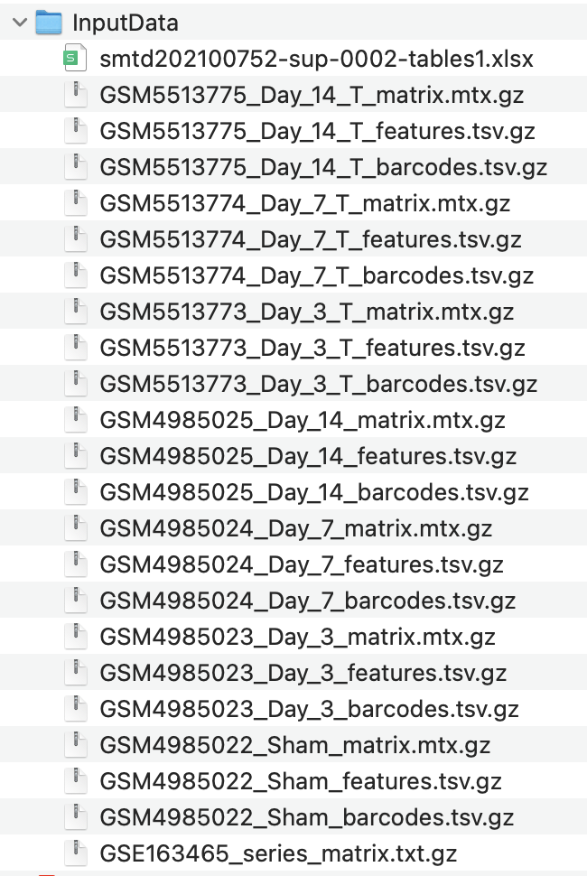

```r
# 设置存放输入数据的路径
# Set data path
data.path <- file.path("InputData")

# 读取样本信息
# Read sample information
sample.info <- getGEO(filename = file.path(data.path,"GSE163465_series_matrix.txt.gz"))
sample.info <- as.data.frame(sample.info)

# 清理样本名称
# Clean sample names
sample.info$title <- gsub("CD45\\+\\ |Cd45\\+\\ |_T", "", sample.info$title)
sample.info <- data.frame(
  "geo" = sample.info$geo_accession,
  "time" = sample.info$title
)

# 读取原文提供的marker，用于髓系细胞亚型注释
# Load marker genes from original publication for myeloid cell subtype annotation
marker <- read.xlsx(xlsxFile = file.path(data.path,"smtd202100752-sup-0002-tables1.xlsx"),
                    sheet = "Mø and Monocyte")
marker <- subset(marker, avg_logFC > 0.5 & p_val_adj < 0.05)
marker <- split(marker$gene, marker$cluster)

# 读取表达矩阵
# Read expression matrices
samples <- list.files(data.path, pattern = "mtx.gz$", full.names = T)
mtx.list <- lapply(samples, function(sample){
  mtx = ReadMtx(mtx = sample,
                cells = gsub("matrix.mtx.gz", "barcodes.tsv.gz", sample),
                features = gsub("matrix.mtx.gz", "features.tsv.gz", sample),
                cell.column = 1, feature.column = 2)
  colnames(mtx) = paste0(substr(basename(sample), 1, 10), colnames(mtx))
  return(mtx)
})

# 合并矩阵
# Merge matrices
mtx <- do.call(cbind, mtx.list)

# 生成Seurat对象
# Create Seurat object
seu <- CreateSeuratObject(mtx, min.cells = 3, min.features = 200)

# 添加样本信息
# Add sample information
seu$Sample <- substr(colnames(seu), 1, 10)
seu$Time <- sample.info$time[match(seu$Sample, sample.info$geo)]

# 标准预处理流程
# Standard preprocessing
seu <- FindVariableFeatures(seu) %>% NormalizeData() %>% ScaleData()
```

```
## Finding variable features for layer counts
```

```
## Normalizing layer: counts
```

```r
seu <- RunPCA(seu)
```

[output not shown]

```r
seu <- RunUMAP(seu, dims = 1:50)
seu <- FindNeighbors(seu, dims = 1:50) %>% FindClusters()
```

```
## Modularity Optimizer version 1.3.0 by Ludo Waltman and Nees Jan van Eck
##
## Number of nodes: 37879
## Number of edges: 1552225
##
## Running Louvain algorithm...
## Maximum modularity in 10 random starts: 0.9152
## Number of communities: 33
## Elapsed time: 9 seconds
```

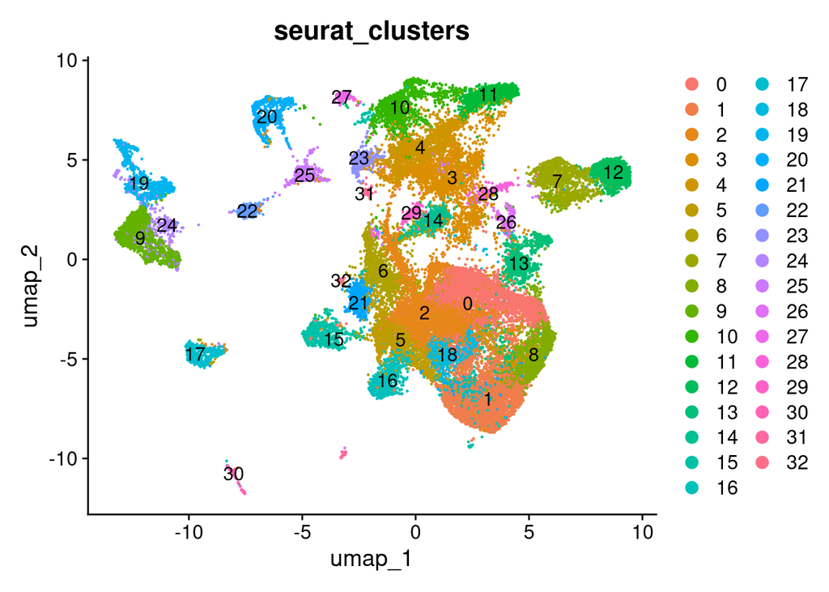

```r
# 可视化聚类
# Visualize clustering
DimPlot(seu, group.by = "seurat_clusters", label = T)
```

```r
# 注释细胞类型
# Cell type annotation
SingleR.ref <- MouseRNAseqData()
```

```r
# 其他的参考集可以通过celldex包获取: http://bioconductor.org/packages/release/data/experiment/html/celldex.html
# Additional reference datasets available via celldex package: http://bioconductor.org/packages/release/data/experiment/html/celldex.html

anno <- SingleR(
    test = LayerData(seu, assay = "RNA", layer = "data"),
    clusters = seu$seurat_clusters,
    ref = SingleR.ref,
    labels = SingleR.ref$label.main
)
anno <- as.data.frame(anno)

# 添加注释结果
# Add annotation results
seu$Celltypes <- mapvalues(x = seu$seurat_clusters,
                           from = rownames(anno),
                           to = anno$pruned.labels)

#提取髓系细胞
# Subset myeloid cells
seu <- subset(seu, Celltypes %in% c("Macrophages", "Monocytes"))
# 重新聚类
# Re-clustering
seu <- FindVariableFeatures(seu) %>% NormalizeData() %>% ScaleData()
```

```
## Finding variable features for layer counts
## Normalizing layer: counts
```

```r
seu <- RunPCA(seu)
```

[output not shown]

```r
seu <- RunUMAP(seu, dims = 1:50)
seu <- FindNeighbors(seu, dims = 1:50) %>% FindClusters()
```

```
## Modularity Optimizer version 1.3.0 by Ludo Waltman and Nees Jan van Eck
##
## Number of nodes: 22173
## Number of edges: 854341
##
## Running Louvain algorithm...
## Maximum modularity in 10 random starts: 0.8776
## Number of communities: 24
## Elapsed time: 3 seconds
```

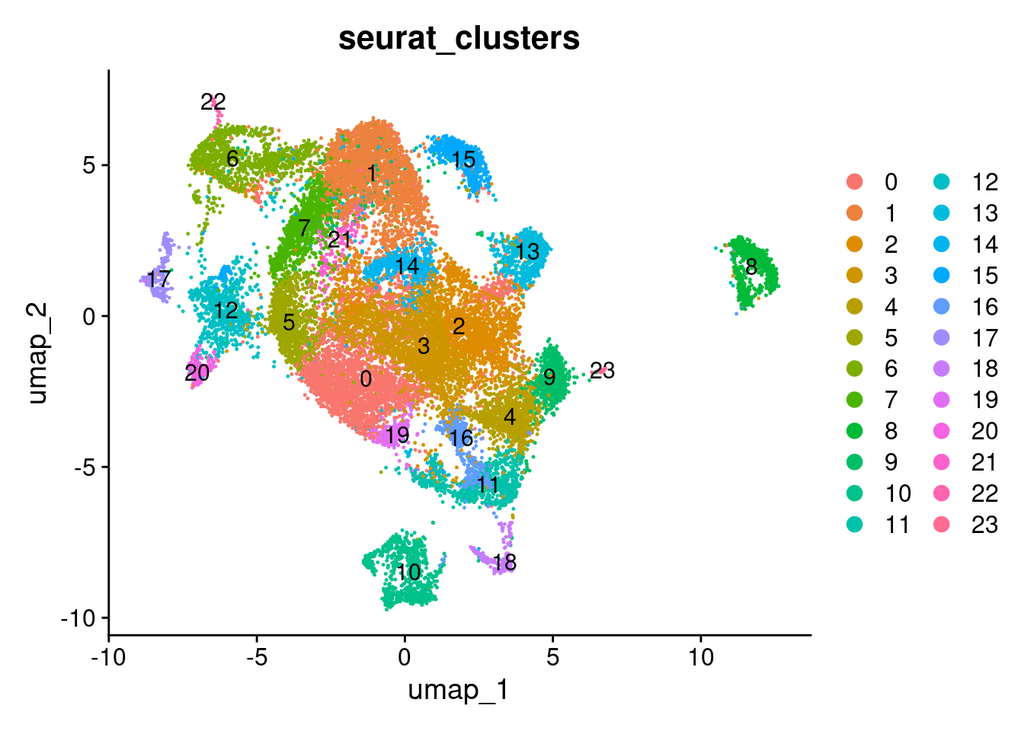

```r
DimPlot(seu, group.by = "seurat_clusters", label = T)
```

```r
# GSVA分析
# GSVA analysis
expr.mat <- as.matrix(AverageExpression(seu, assays = "RNA", layer = "data")[[1]])
```

```
## As of Seurat v5, we recommend using AggregateExpression to perform pseudo-bulk analysis.
## First group.by variable `ident` starts with a number, appending `g` to ensure valid variable names
```

```r
param <- gsvaParam(
  exprData = expr.mat,
  geneSets = marker,
  minSize = 5,
  maxSize = 500,
  kcdf = "Gaussian"
)
marker.score <- gsva(param, verbose = FALSE)
```

```
## ! 708 genes with constant values throughout the samples
## ! Genes with constant values are discarded
```

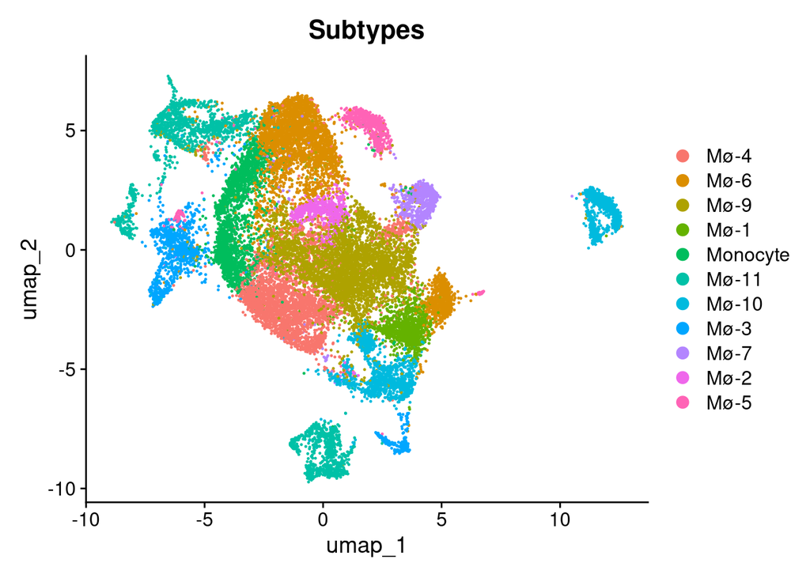

```r
anno <- apply(marker.score, 2, which.max)
anno <- data.frame(clusters = levels(Idents(seu)), label = names(marker)[anno])
seu$Subtypes <- mapvalues(seu$seurat_clusters,
                          from = anno$clusters, to = anno$label)
DimPlot(seu, group.by = "Subtypes")
```

```r
# 保存seu对象
# Save seu object
saveRDS(seu, "seu.rds")
```